# Zhaoxin Ban HW3

Question 1 a

```r
setwd("C:/Users/zban/Downloads/2019 winter quarter/Modern Environmental Statistics/")
Tmax=read.table("USW00023174_TMAX_clean.csv",sep=",",header=T)
Tmin=read.table("USW00023174_TMIN_clean.csv",sep=",",header=T)
ind1 <- which(Tmax[,5]!=-999.9)
ind2 <- which(Tmin[,5]!=-999.9)
ind <- intersect(ind1,ind2)
Tmax=Tmax[ind,]
Tmin=Tmin[ind,]
Tmax_DJF <- Tmax[which((Tmax[,2]==12)|(Tmax[,2]==1)|(Tmax[,2]==2)),5]
Tmin_DJF <- Tmin[which((Tmin[,2]==12)|(Tmin[,2]==1)|(Tmin[,2]==2)),5]
Date_DJF <- Tmax[which((Tmax[,2]==12)|(Tmax[,2]==1)|(Tmax[,2]==2)),1:3]
for(i in 1:length(HDD)){
  HDD[i]=max(15-0.5*(Tmax_DJF[i]+Tmin_DJF[i]),0)
}
HDD_wd <- cbind(Date_DJF,HDD)
lDJF <- length(unique(Date_DJF[,1]))-1
seas_HDD <- rep(0,lDJF)
for(i in 1:lDJF){
  D <- HDD_wd[which((HDD_wd[,1]*100+HDD_wd[,2])==((unique(Date[,1])[i]))*100+12),]
  J <- HDD_wd[which((HDD_wd[,1]*100+HDD_wd[,2])==((unique(Date[,1])[i+1])*100+1)),]
  F <- HDD_wd[which((HDD_wd[,1]*100+HDD_wd[,2])==((unique(Date[,1])[i+1])*100+2)),]
  seas_HDD[i]=mean(c(D[,4],J[,4],F[,4]))
}###The winter HDD is stored in seas_HDD
###Download climate indices
nyr=2018-1944+1
month=rep(seq(1,12),nyr)
NINO3.4=read.table("NINO3.4.txt",skip=40)
NINO3.4=NINO3.4[which(NINO3.4[,1]>=1944),]
year=c(floor(NINO3.4[,1]),2018)
NINO3.4=cbind(year[1:length(NINO3.4[,2])],month[1:length(NINO3.4[,2])],NINO3.4[,2])
NINO4=read.table("NINO4.txt",skip=40)
NINO4=NINO4[which(NINO4[,1]>=1944),]
NINO4=cbind(year[1:length(NINO4[,2])],month[1:length(NINO4[,2])],NINO4[,2])
SOI=read.table("SOI Jones.txt",skip=40)
getindex <- function(index){
  index1=index[which(index[,1]>=1944),]
  tmp=rep(0,12*nyr)
  for(i in 1:nyr){
    tmp[((i-1)*12+1):(i*12)]=as.numeric(index1[i,2:13])
  }
  index2=cbind(year[1:length(tmp)],month[1:length(tmp)],tmp)
}
SOI=getindex(SOI)
PDO=read.table("PDO.txt",skip=40)
```

```
number of items read is not a multiple of the number of columns
```

```r
PDO=getindex(PDO)
NAO=read.table("NAO.txt",skip=40)
NAO=getindex(NAO)
AMO=read.table("AMO.txt",skip=40)
AMO=getindex(AMO)
landT=read.table("landtemp.txt",skip=40)
landT=landT[which(landT[,1]>=1944),]
###create predictors for winter HDD###
getSON <- function(index){
  index=index[which(index[,3]!=-999.9),]
  tmp=index[which((index[,2]==9)|(index[,2]==10)|(index[,2]==11)),]
  l=length(unique(tmp[,1]))-1
  out=rep(0,l)
  for(i in 1:l){
    out[i]=mean(tmp[which(tmp[,1]==unique(tmp[,1])[i]),3])
  }
  out1 <- cbind(unique(tmp[,1])[2:(l+1)],out)
  return(out1)
}
NINO3.4SON=getSON(NINO3.4)
NINO4SON=getSON(NINO4)
SOISON=getSON(SOI)
NAOSON=getSON(NAO)
PDOSON=getSON(PDO)
AMOSON=getSON(AMO)
landTSON=getSON(landT)
seas_HDD=cbind(landTSON[,1],seas_HDD)
Tmin_SON=getSON(Tmin[c(1,2,5)])
Tmax_SON=getSON(Tmax[c(1,2,5)])
SON <- cbind(NINO3.4SON,NINO4SON[,2],SOISON[,2],NAOSON[,2],PDOSON[,2],AMOSON[,2],landTSON[,2],Tmin_SON[,2],Tmax_SON[,2])
k=ncol(SON)
n=nrow(SON)
tmpSON=array(0,dim=c(n,k))
pdSON=array(0,dim=c(n,k+1))
for(i in 1:k){
  tmpSON[,i]=(SON[,i]-mean(SON[,i]))/sd(SON[,i])
}
pdSON=as.data.frame(cbind(seas_HDD[,2],tmpSON))
names(pdSON)=c("HDD","time","NINO3.4","NINO4","SOI","NAO","PDO","AMO","landT","Tmin","Tmax")
pdSON  ##This is the dataframe with normalized predictors
```

| HDD | time | NINO3.4 | NINO4 | SOI | NAO | PDO | AMO | landT | Tmin | Tmax |
| --- | --- | --- | --- | --- | --- | --- | --- | --- | --- | --- |
| 2.4361111 | -1.69721553 | -0.221547697 | 0.129399480 | -0.558300861 | 0.35337633 | 0.05573006 | 1.03114751 | -0.030158453 | -1.706738335 | -2.30242704 |
| 3.1011494 | -1.65071647 | -0.665111264 | -0.387361331 | 0.257037166 | 0.01013254 | -0.45120981 | 0.12199999 | -0.443769439 | -1.842665581 | -0.76118363 |
| 2.8466667 | -1.60421741 | -0.033177614 | 0.359335881 | -1.131798217 | -0.21996537 | -0.43408346 | -0.28052732 | -0.663071950 | -2.549719949 | -1.02470887 |
| 3.0061111 | -1.55771836 | -0.836820084 | -0.960249570 | 0.600473002 | 0.38209532 | 0.71338178 | 0.88536709 | -0.108365599 | -2.279770413 | -0.89654993 |
| 4.8483333 | -1.51121930 | -0.258912961 | -0.189485994 | 0.035073811 | 1.58275657 | -1.08145937 | 0.83399555 | -0.453444550 | -2.464931854 | -0.71132722 |
| 4.0872222 | -1.46472025 | -0.877570363 | -1.213338206 | -0.029343414 | 0.27310157 | -0.81428836 | 1.22593459 | -0.542133065 | -1.362023678 | 0.05283109 |
| 2.3966667 | -1.41822119 | -1.096884768 | -1.498901190 | 1.229185124 | 1.29764277 | -1.76993851 | -0.11189820 | -1.391930295 | -0.974727937 | -0.67302108 |
| 2.8405556 | -1.37172214 | 0.928934565 | 0.470925178 | -1.273516113 | -0.22169543 | 0.03860371 | 0.16549597 | -0.305899111 | -0.901004129 | -0.19959653 |
| 1.8061111 | -1.32522308 | -0.159448666 | -0.002540592 | -0.078668604 | -1.18568455 | -0.41353185 | 0.84440543 | -1.029113641 | -1.265691235 | -1.40083766 |
| 2.0400000 | -1.27872403 | 0.502473367 | 0.445711687 | -0.650693567 | 1.88413292 | -0.32790011 | 0.72417645 | -0.435706847 | -1.494726534 | -0.31647935 |

[output cut: 64 more lines]

b

```r
library(glmnet)
xminus <- seas_HDD[1:60,2]
xplus <- seas_HDD[2:61,2]
r1 <- sum((xminus-mean(xminus))*(xplus-mean(xplus)))/((sqrt(sum((xminus-mean(xminus))^2)))*(sqrt(sum((xminus-mean(xminus))^2))))
n1 <- n*(1-r1)/(1+r1)
expon <- 2/3*(1-n1/n) ###Now the Wilks 5.36 becomes L=(101-L)^(expon)
fL <- function(L,expon){
  n=100
  result <- L-(n-L+1)^expon
  return(result)
}
##Check the approximate location of root of fL##
L=seq(-100,100,0.1)
eps=1e-7
max=max(L)
min=min(L)
tmp=0.5*(max+min)
check <- fL(tmp,expon)
while(abs(check)>eps){
  if(check<0){
    min=tmp
    tmp=0.5*(max+min)
  }else{
    max=tmp
    tmp=0.5*(max+min)
  }
  check <- fL(tmp,expon)
}
L <- round(tmp)
###moving window cross validation with overlap###
nblock <- floor(61/L)
lambda=seq(0,5,by=0.01)
MSE=array(0,dim=c(length(lambda),nblock))
meanMSE=rep(0,length(lambda))
for(i in 1:length(lambda)){
  for(j in 1:nblock){
    if(j==1){
      xtest=pdSON[1:L,]
      xtrain=pdSON[(L+1):61,]
    }else if(j>1){
      xtest=pdSON[((j-1)*L+1):(j*L),]
      xtrain=rbind(pdSON[1:((j-1)*L),],pdSON[(j*L+1):61,])
    }
    ridge_mod = glmnet(as.matrix(xtrain[,2:11]), xtrain[,1], alpha=0, lambda = lambda[i], nlambda=1)
    ridge_pred = predict(ridge_mod, newx = as.matrix(xtest[,2:11]))
    MSE[i,j]=sqrt(mean((ridge_pred - xtest[,1])^2))
  }
  meanMSE[i]=mean(MSE[i,])
}
lam=lambda[which(meanMSE==min(meanMSE))]
print(paste0("lambda=",lam))
```

```
[1] "lambda=0.99"
```

c

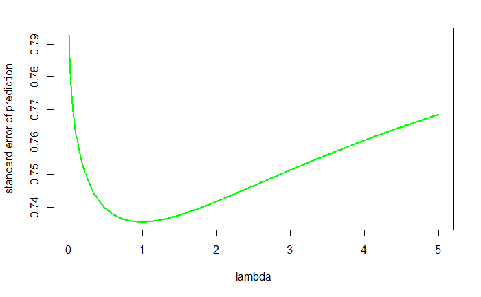

```r
plot(x=lambda,y=meanMSE,type='l',col="green",ylab="standard error of prediction",lwd=2)
```

When lambda is small, the variance of the parameter is ignored when considering a cost function in regression, and the performance of the prediction is not good enough because of the possible large variance of the parameters, which making the model is better at fitting training data than predicting new data. When lambda is large, the variance of the parameter is better controled, however, the fit to the original training dataset has relative smaller weight, under this condition, the model tends to capture less of the information from the training data, and making the prediction less accurate. Only when the balance between model parameter variance and the fit to the training data is obtained, the model can perform an overall best prediction to the new datas. The beta can only approaching zero, so the standard error of prediction will keep changing.

d

```r
ridge_mod = glmnet(as.matrix(pdSON[1:61,2:11]), pdSON[1:61,1], alpha=0, lambda = lam, nlambda=1)
ridge_mod$beta
```

```
10 x 1 sparse Matrix of class "dgCMatrix"
                 s0
time    -0.15315143
NINO3.4 -0.01789179
NINO4   -0.05375989
SOI      0.01307204
NAO      0.05995604
PDO     -0.05179389
AMO      0.04916314
landT   -0.03273764
Tmin    -0.16172245
Tmax    -0.05741470
```

In my model for HDD in HW2, the pertained variables (ordered in terms of their relative importance) are: Tmin,time,NINO4,landT,NAO,AMO. The left-out variables are Tmax, SOI, PDO and NINO3.4. In ridge regression model, the variables order in terms of their beta absolute magnitude is: Tmin, time, NAO, Tmax, NINO4, PDO, AMO, landT, NINO3.4, SOI. The two models didn’t select exactly the same set of important variables, but the overall pattern is similar (note I didn’t include PDO, SOI, and NINO3.4 at first in the HW2 stepwise procedure for HDD.)

e

```r
df_HDD <- as.data.frame(cbind(seas_HDD[,2],NINO4SON,NAOSON[,2],AMOSON[,2],landTSON[,2],Tmin_SON[,2],Tmax_SON[,2]))
colnames(df_HDD) <- c("HDD","time","NINO4","NAO","AMO","landT","Tmin","Tmax")
newytest=pdSON[62:74,1]
#original model for HDD in HW2
md1 <-lm(HDD~Tmin+time+NINO4+landT+NAO+AMO,data=df_HDD)
pdHDD <- predict(md1,df_HDD[which(df_HDD[,2]>2005),])
ridge_pred = predict(ridge_mod, newx = as.matrix(pdSON[62:74,2:11]))
index=seq(1,13,by=1)
plot(x=index,y=newytest,col="red",lwd=2,ylim=c(0,5))
lines(x=index,y=ridge_pred,col="black",lwd=2)
```

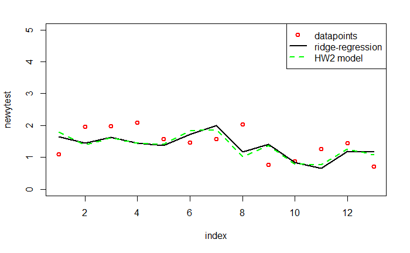

```r
lines(x=index,y=pdHDD,col="green",lwd=2,lty=2)
legend("topright",c("datapoints","ridge-regression","HW2 model"),col=c("red","black","green"),lty=c(NA,1,2),pch=c(1,NA,NA),lwd=c(2,2,2))
```

```r
std1=sqrt(mean((newytest-ridge_pred)^2))
std2=sqrt(mean((pdHDD-newytest)^2))
print(paste0("The standard errors of ridge-regression and HW2 model are respectively:",std1,", ",std2))
```

```
[1] "The standard errors of ridge-regression and HW2 model are respectively:0.49355747137147, 0.511909013120287"
```

Both the ridge regression model and HW2 model captured the mean magnitude of the data points. The variance between the predicted value of ridge-regression is similar to that of HW2 model. Overall, the ridge-regression model performs slightly better than the HW2 model in terms of standard error.

f

```r
###moving window cross validation with overlap###
nblock <- floor(61/L)
lambda=seq(0,5,by=0.01)
MSE=array(0,dim=c(length(lambda),nblock))
meanMSE=rep(0,length(lambda))
for(i in 1:length(lambda)){
  for(j in 1:nblock){
    if(j==1){
      xtest=pdSON[1:L,]
      xtrain=pdSON[(L+1):61,]
    }else if(j>1){
      xtest=pdSON[((j-1)*L+1):(j*L),]
      xtrain=rbind(pdSON[1:((j-1)*L),],pdSON[(j*L+1):61,])
    }
    lasso_mod = glmnet(as.matrix(xtrain[,2:11]), xtrain[,1], alpha=1, lambda = lambda[i], nlambda=1)
    lasso_pred = predict(lasso_mod, newx = as.matrix(xtest[,2:11]))
    MSE[i,j]=sqrt(mean((lasso_pred - xtest[,1])^2))
  }
  meanMSE[i]=mean(MSE[i,])
}
lam=lambda[which(meanMSE==min(meanMSE))]
print(paste0("lambda=",lam))
```

```
[1] "lambda=0.06"
```

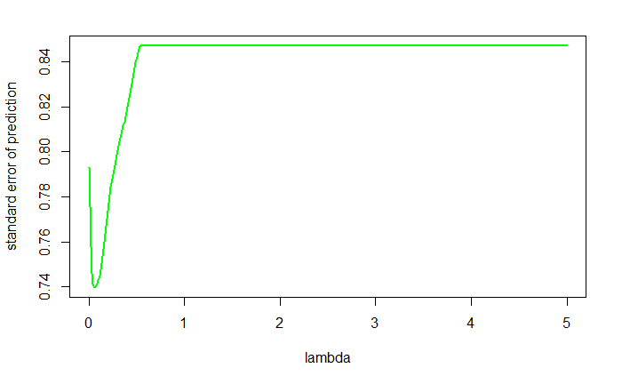

```r
plot(x=lambda,y=meanMSE,type='l',col="green",ylab="standard error of prediction",lwd=2)
```

Answer to c in LASSO regression: When lambda is small, the variance of the parameter is ignored when considering a cost function in regression, and the performance of the prediction is not good enough because of the possible large variance of the parameters, which making the model is better at fitting training data than predicting new data. When lambda is large, the variance of the parameter is better controled, however, the fit to the original training dataset has relative smaller weight, under this condition, the model tends to capture less of the information from the training data, and making the prediction less accurate. Only when the balance between model parameter variance and the fit to the training data is obtained, the model can perform an overall best prediction to the new datas. When lambda is very large, the beta can be zero, then the corresponding predictor can be negligible, and when all of the beta becomes zero, the model’s standard error of prediction becomes the standard error of prediction when all of the predicted value becomes the interception.

```r
lasso_mod = glmnet(as.matrix(pdSON[1:61,2:11]), pdSON[1:61,1], alpha=1, lambda = lam, nlambda=1)
lasso_mod$beta
```

```
10 x 1 sparse Matrix of class "dgCMatrix"
                  s0
time    -0.196619621
NINO3.4  .
NINO4   -0.083300367
SOI      .
NAO      0.018175842
PDO     -0.007099081
AMO      .
landT    .
Tmin    -0.345650163
Tmax     .
```

The parameters that the lasso regression pertained (ordered by absolute magnitude of beta): Tmin, time, NINO4, NAO and PDO. In my model for HDD in HW2, the pertained variables (ordered in terms of their relative importance) are: Tmin,time,NINO4,landT,NAO,AMO. The left-out variables are Tmax, SOI, PDO and NINO3.4. The two models didn’t select exactly the same set of important variables (PDO), but the overall pattern is similar (note I didn’t include PDO, SOI, and NINO3.4 at first in the HW2 stepwise procedure for HDD.) If we don’t consider PDO, then the order of relative importance of the variables pertained is more consistent between the HW2 model and lasso-regression model.

```r
lasso_pred = predict(lasso_mod, newx = as.matrix(pdSON[62:74,2:11]))
index=seq(1,13,by=1)
plot(x=index,y=newytest,col="red",lwd=2,ylim=c(0,5))
lines(x=index,y=lasso_pred,col="black",lwd=2)
```

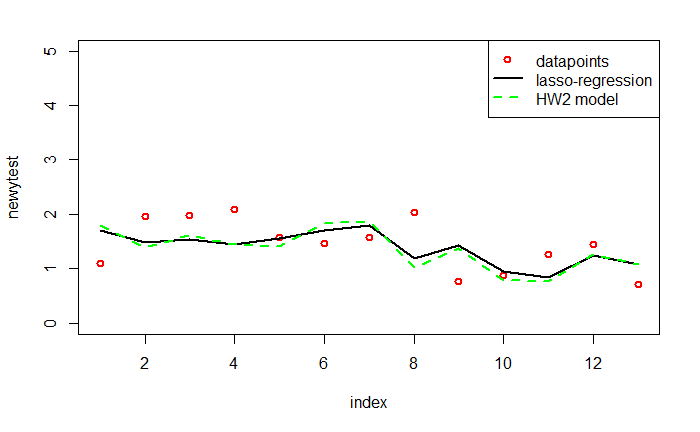

```r
lines(x=index,y=pdHDD,col="green",lwd=2,lty=2)
legend("topright",c("datapoints","lasso-regression","HW2 model"),col=c("red","black","green"),lty=c(NA,1,2),pch=c(1,NA,NA),lwd=c(2,2,2))
```

```r
std1=sqrt(mean((newytest-lasso_pred)^2))
std2=sqrt(mean((pdHDD-newytest)^2))
print(paste0("The standard errors of lasso-regression and HW2 model are respectively:",std1,", ",std2))
```

```
[1] "The standard errors of lasso-regression and HW2 model are respectively:0.46452598103174, 0.511909013120287"
```

Both models control the relative magnitude of the data well. The variance of the predicted value of lasso-regression is smaller than that of HW2 model, probably because the lasso-regression model has a control on the variance of the parameters. Overall, the lasso-regression model performs better than the HW2 model in terms of standard error.

Question 2

a

```r
library(ncdf4)
nc <- nc_open("pres.sfc.mon.mean.nc")
nc
```

```
File pres.sfc.mon.mean.nc (NC_FORMAT_NETCDF4_CLASSIC):

     2 variables (excluding dimension variables):
        double time_bnds[nbnds,time]
            long_name: Time Boundaries
        float pres[lon,lat,time]
            cell_methods: time: mean (monthly from 6-hourly values)
            long_name: Monthly Pressure at Surface
            units: Pa
            precision: 0
            GRIB_id: 1
            GRIB_name: PRES
            var_desc: Pressure
            dataset: NOAA-CIRES 20th Century Reanalysis version 2 Monthly Averages
            level_desc: Surface
            statistic: Ensemble Mean
            parent_stat: Individual Obs
            standard_name: air_pressure
            missing_value: -9.96920996838687e+36
            valid_range: 46500
             valid_range: 112000
            actual_range: 48952.91015625
             actual_range: 108376
            statistic_method: Ensemble mean is calculated by averaging over all 56 ensemble members at each time step and then averaging mean over all time steps in a month

     4 dimensions:
        lat  Size:91
            units: degrees_north
            actual_range: 90
             actual_range: -90
            long_name: Latitude
            standard_name: latitude
            axis: Y
            coordinate_defines: point
        lon  Size:180
            units: degrees_east
            long_name: Longitude
            actual_range: 0
             actual_range: 358
            standard_name: longitude
```

[output cut: 19 more lines]

```
NOAA-CIRES 20th Century Reanalysis version 2
(4x/day).  It consists of most variables interpolated to
pressure surfaces from model (sigma) surfaces.
        platform: Model
        institution: NOAA ESRL/PSD
        version: 2.0
        history: created by NOAA/ESRL/PSD web&data
Converted to chunked, deflated non-packed NetCDF4 2014/05
        dataset_title: NOAA-CIRES 20th Century Reanalysis (V2)
        References: https://www.esrl.noaa.gov/psd/data/gridded/data.20thC_ReanV2.html
        citation: Compo,G.P. <https://www.esrl.noaa.gov/psd/people/gilbert.p.compo>,
J.S. Whitaker <https://www.esrl.noaa.gov/psd/people/jeffrey.s.whitaker>,
 and P.D. Sardeshmukh, 2006: Feasibility of a 100 year reanalysis using
only surface pressure data.
/Bull. Amer. Met. Soc./, 87, 175-190.
```

The original data information is as shown above, and the cutted data has same information except the latitude is confined within (0,50) degree N and the longitude is confined within (125,67) degree west.

```r
library(raster)
LonIdx <- which( nc$dim$lon$vals > 235 & nc$dim$lon$vals < 293)
LatIdx <- which( nc$dim$lat$vals > 0 & nc$dim$lat$vals < 50)
lon=nc$dim$lon$vals[LonIdx]
lat=nc$dim$lat$vals[LatIdx]
test <- ncvar_get(nc,"pres")
pres <- ncvar_get( nc, "pres")[ LonIdx, LatIdx,]
nc_close(nc)
dim=dim(pres)
```

2. I am going to start from monthly scale of variability, and if needed, will shift to decadal scale to see time patterns

```r
library(raster)
rmannual=array(0,dim=dim)
for(i in 1:dim[1]){
  for(j in 1:dim[2]){
    yr=rep(1871:2012,each=12)
    mon=rep(c(1:12),2012-1871+1)
    time=cbind(yr,mon)
    prestmp=pres[i,j,]
    preswd=cbind(time,prestmp)
    presclim=rep(0,12)
    for(k in 1:12){
      presclim[k]=mean(preswd[which(preswd[,2]==k),3])
    }
    presclimnew=rep(presclim,2012-1871+1)
    presnew=prestmp-presclimnew
    rmannual[i,j,]=presnew  ##Here I removed annual cycle
  }
}
```

```r
datanew=array(0,dim=c(dim[1]*dim[2],dim[3]))
for(i in 1:dim[1]){
  for(j in 1:dim[2]){
    datanew[(i-1)*dim[2]+j,]=rmannual[i,j,]
  }
}
C=(datanew)%*%t(datanew)/dim[3]
eig <- eigen(C)
```

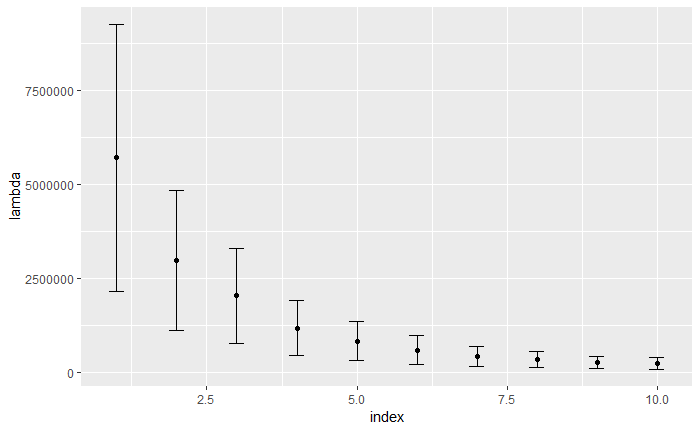

```r
sorteig <- sort(eig$values,decreasing = TRUE)
variance=sorteig/sum(sorteig)
m=length(datanew[,1])
meff=(m*mean(sorteig))^2/(m*mean(sorteig^2))
sigmalam=sorteig*sqrt(2/meff)
library(ggplot2)
x=c(1:10)
y=as.numeric(sorteig[1:10])
sd=sigmalam[1:10]
qplot(x,y,xlab="index",ylab="lambda")+geom_errorbar(aes(x=x, ymin=y-sd, ymax=y+sd), width=0.25)
```

```r
i=1
summ=sum(variance[1:i])
while(summ<0.8){
  i=i+1
  summ=sum(variance[1:i])
}
i
```

```
[1] 5
```

Choose the first five eigenvectors, the criterion I based on is to set the total contributing variance=80%.

```r
eigvec <- eig$vectors[,1:5]
times <- t(eigvec)%*%datanew
```

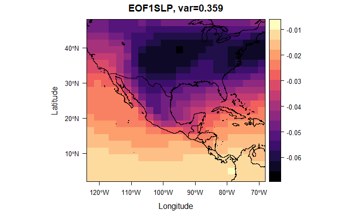

```r
vec2mx <- function(vec){
  mat <- array(0,dim=c(dim[1],dim[2]))
  for(i in 1:dim[1]){
    for(j in 1:dim[2]){
      mat[i,j]=vec[(i-1)*dim[2]+j]
    }
  }
  return(mat)
}
mat1 <- vec2mx(eigvec[,1])
mat2 <- vec2mx(eigvec[,2])
mat3 <- vec2mx(eigvec[,3])
mat4 <- vec2mx(eigvec[,4])
mat5 <- vec2mx(eigvec[,5])
rotate <- function(x) {t(apply(x, 2, rev))}
library(lattice)
library(raster)
library(rasterVis)
library(maps)
library(mapdata)
library(maptools)
## raster
plotmat <- function(mat1,x){
r <-raster(rotate(mat1)[,24:1],  xmn=-124, xmx=-68, ymn=2, ymx=48,
           crs=CRS("+proj=longlat +datum=WGS84 +ellps=WGS84 +towgs84=0,0,0")
)
## polygon shapefile
ext <- as.vector(extent(r))
boundaries <- map('worldHires', fill=TRUE,
                  xlim=ext[1:2], ylim=ext[3:4],
                  plot=FALSE)
## read the map2SpatialPolygons help page for details
IDs <- sapply(strsplit(boundaries$names, ":"), function(x) x[1])
bPols <- map2SpatialPolygons(boundaries, IDs=IDs,
                             proj4string=CRS(projection(r)))
levelplot(r,margin=FALSE,main=paste0("EOF",x,"SLP, var=",round(variance[x],3))) + layer(sp.polygons(bPols))
}
avgtime=array(0,dim=c(5,1585))
for(i in 1:1585){
  for(k in 1:5){
    avgtime[k,i]=mean(times[k,i:(i+119)])
  }
}
plotmat(mat1,1)
```

```r
plot(times[1,],type='l',xlab="Months since Jan 1871",ylab="Time series (Pa)",main="PC1TS (Pa)")
lines(avgtime[1,],col="red",lwd=2)
```

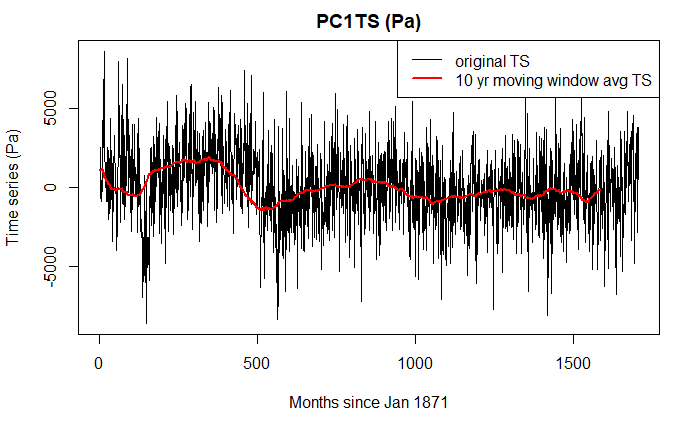

```r
legend("topright",c("original TS","10 yr moving window avg TS"),lwd=c(1,2),col=c("black","red"))
```

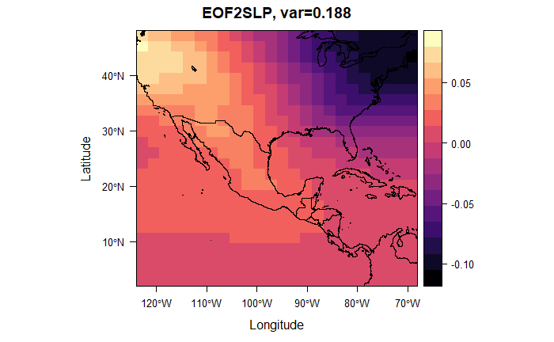

```r
plotmat(mat2,2)
```

```r
plot(times[2,],type='l',xlab="Months since Jan 1871",ylab="Time series (Pa)",main="PC2TS (Pa)")
lines(avgtime[2,],col="red",lwd=2)
```

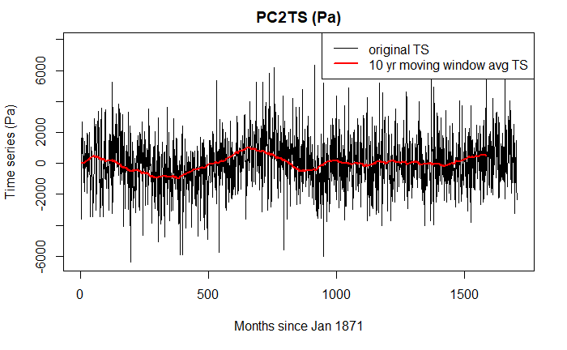

```r
legend("topright",c("original TS","10 yr moving window avg TS"),lwd=c(1,2),col=c("black","red"))
```

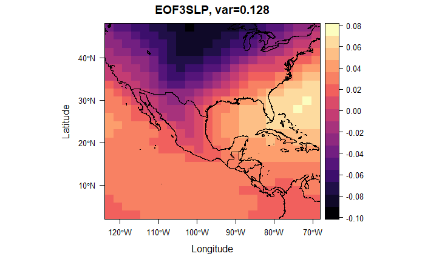

```r
plotmat(mat3,3)
```

```r
plot(times[3,],type='l',xlab="Months since Jan 1871",ylab="Time series (Pa)",main="PC3TS (Pa)")
lines(avgtime[3,],col="red",lwd=2)
```

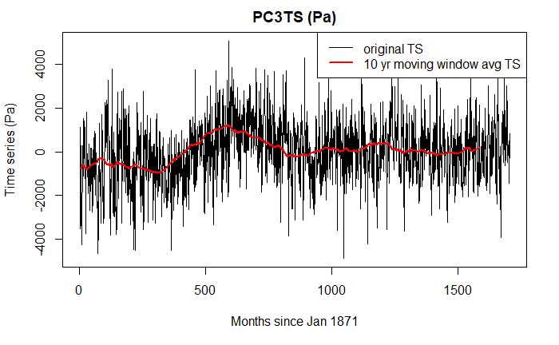

```r
legend("topright",c("original TS","10 yr moving window avg TS"),lwd=c(1,2),col=c("black","red"))
```

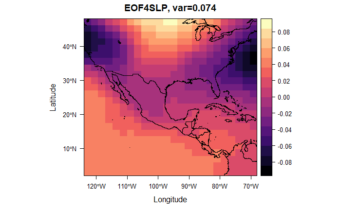

```r
plotmat(mat4,4)
```

```r
plot(times[4,],type='l',xlab="Months since Jan 1871",ylab="Time series (Pa)",main="PC4TS (Pa)")
lines(avgtime[4,],col="red",lwd=2)
```

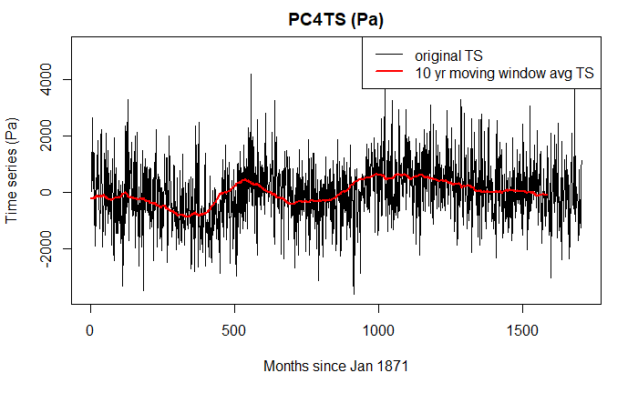

```r
legend("topright",c("original TS","10 yr moving window avg TS"),lwd=c(1,2),col=c("black","red"))
```

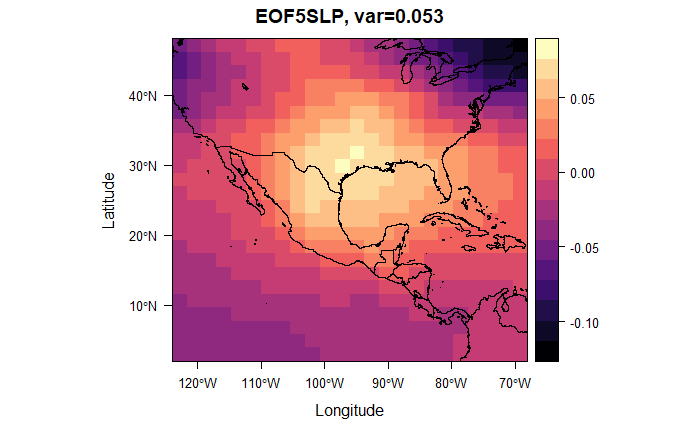

```r
plotmat(mat5,5)
```

```r
plot(times[5,],type='l',xlab="Months since Jan 1871",ylab="Time series (Pa)",main="PC5TS (Pa)")
lines(avgtime[5,],col="red",lwd=2)
```

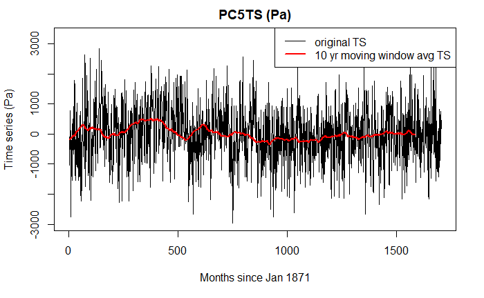

```r
legend("topright",c("original TS","10 yr moving window avg TS"),lwd=c(1,2),col=c("black","red"))
```

```r
scaledata=array(0,dim=dim(rmannual))
for(i in 1:24){
  for(j in 1:dim[3]){
    scaledata[,i,j]=rmannual[,i,j]*cos(pi*(lat[i]/180))
  }
}
scdatanew=array(0,dim=c(dim[1]*dim[2],dim[3]))
for(i in 1:dim[1]){
  for(j in 1:dim[2]){
    scdatanew[(i-1)*dim[2]+j,]=scaledata[i,j,]
  }
}
scC=(scdatanew)%*%t(scdatanew)/dim[3]
sceig <- eigen(scC)
scsorteig <- sort(sceig$values,decreasing = TRUE)
scvariance=scsorteig/sum(scsorteig)
scmeff=(m*mean(scsorteig))^2/(m*mean(scsorteig^2))
scsigmalam=scsorteig*sqrt(2/scmeff)
i=1
summ=sum(scvariance[1:i])
while(summ<0.8){
  i=i+1
  summ=sum(scvariance[1:i])
}
i
```

```
[1] 6
```

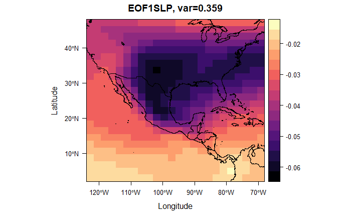

```r
sceigvec <- sceig$vectors[,1:6]
sctimes <- t(sceigvec)%*%datanew
scmat1 <- vec2mx(sceigvec[,1])
scmat2 <- vec2mx(sceigvec[,2])
scmat3 <- vec2mx(sceigvec[,3])
scmat4 <- vec2mx(sceigvec[,4])
scmat5 <- vec2mx(sceigvec[,5])
scmat6 <- vec2mx(sceigvec[,6])
scavgtime=array(0,dim=c(6,1585))
for(i in 1:1585){
  for(k in 1:6){
    scavgtime[k,i]=mean(sctimes[k,i:(i+119)])
  }
}
plotmat(scmat1,1)
```

```r
plot(sctimes[1,],type='l',xlab="Months since Jan 1871",ylab="Time series (Pa)",main="PC1TS (Pa)")
lines(scavgtime[1,],col="red",lwd=2)
```

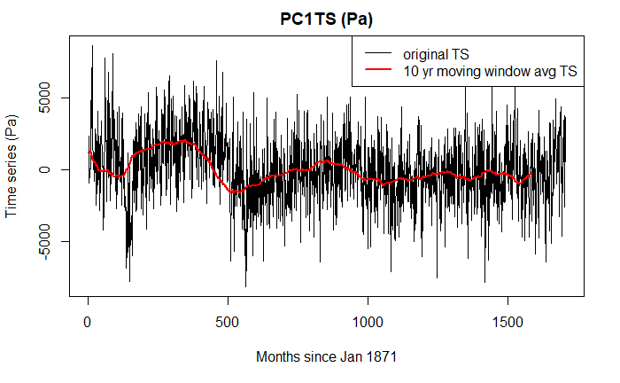

```r
legend("topright",c("original TS","10 yr moving window avg TS"),lwd=c(1,2),col=c("black","red"))
```

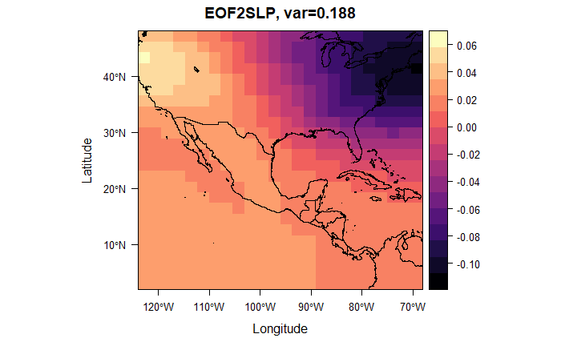

```r
plotmat(scmat2,2)
```

```r
plot(sctimes[2,],type='l',xlab="Months since Jan 1871",ylab="Time series (Pa)",main="PC2TS (Pa)")
lines(scavgtime[2,],col="red",lwd=2)
```

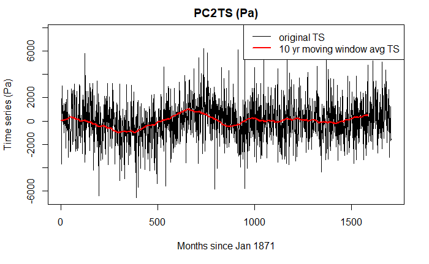

```r
legend("topright",c("original TS","10 yr moving window avg TS"),lwd=c(1,2),col=c("black","red"))
```

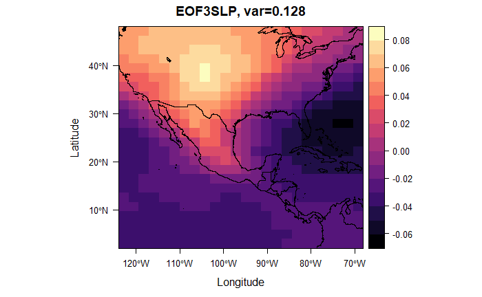

```r
plotmat(scmat3,3)
```

```r
plot(sctimes[3,],type='l',xlab="Months since Jan 1871",ylab="Time series (Pa)",main="PC3TS (Pa)")
lines(scavgtime[3,],col="red",lwd=2)
```

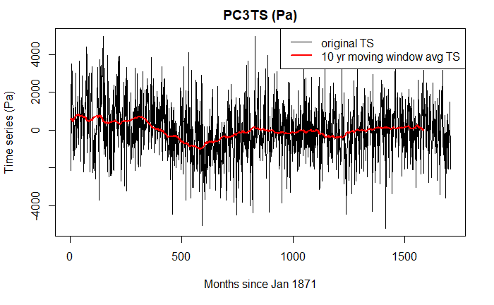

```r
legend("topright",c("original TS","10 yr moving window avg TS"),lwd=c(1,2),col=c("black","red"))
```

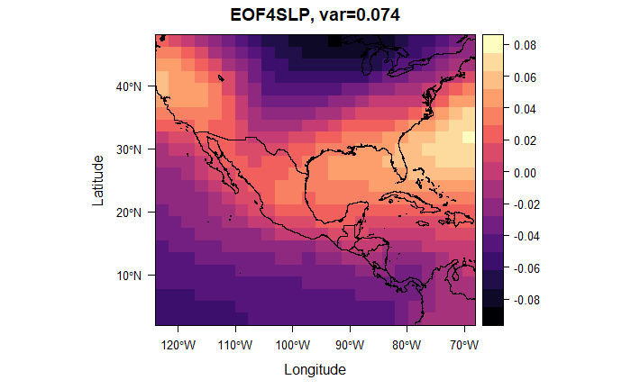

```r
plotmat(scmat4,4)
```

```r
plot(sctimes[4,],type='l',xlab="Months since Jan 1871",ylab="Time series (Pa)",main="PC4TS (Pa)")
lines(scavgtime[4,],col="red",lwd=2)
```

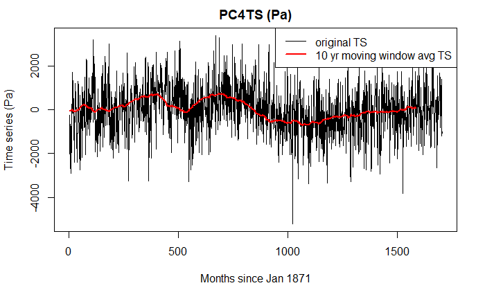

```r
legend("topright",c("original TS","10 yr moving window avg TS"),lwd=c(1,2),col=c("black","red"))
```

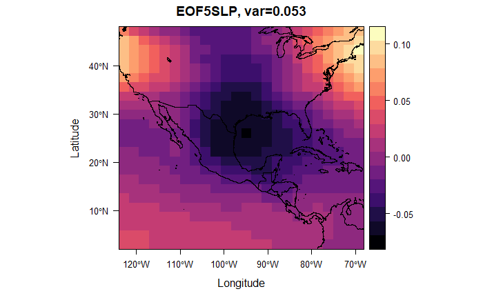

```r
plotmat(scmat5,5)
```

```r
plot(sctimes[5,],type='l',xlab="Months since Jan 1871",ylab="Time series (Pa)",main="PC5TS (Pa)")
lines(scavgtime[5,],col="red",lwd=2)
```

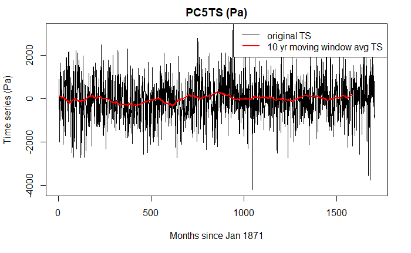

```r
legend("topright",c("original TS","10 yr moving window avg TS"),lwd=c(1,2),col=c("black","red"))
```

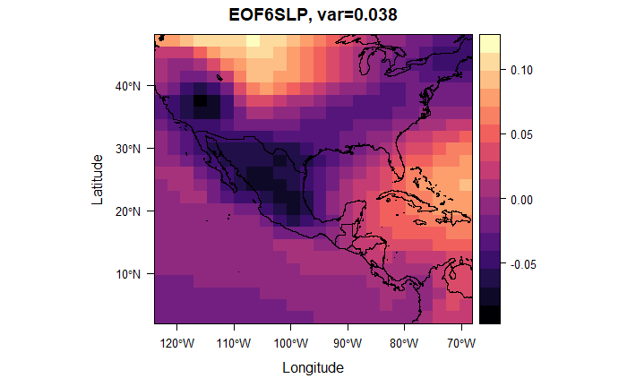

```r
plotmat(scmat6,6)
```

```r
plot(sctimes[6,],type='l',xlab="Months since Jan 1871",ylab="Time series (Pa)",main="PC6TS (Pa)")
lines(scavgtime[6,],col="red",lwd=2)
```

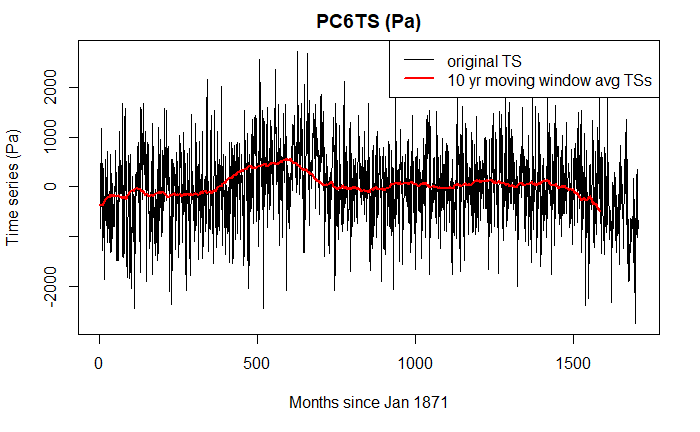

```r
legend("topright",c("original TS","10 yr moving window avg TSs"),lwd=c(1,2),col=c("black","red"))
```

i

After latitude scaling, the spatial patterns of the first two eigenvectors remain similar, while the signs of the spatial patterns of the other eigenvectors (3rd, 4th and 5th) are opposite to that before latitude scaling. This change in sign but mirrored pattern of the 3rd-5th eigenvector might indicating that although the signs changed, the spatial structure revealed by the eigenvectors remains the same. The first eigenvector map shows similar pattern to Pacific/North American Pattern. It is important to note that the PNA has been found to be strongly influenced by the El Niño-Southern Oscillation (ENSO) phenomenon. The positive phase of the PNA pattern tends to be associated with Pacific warm episodes (El Niño), and the negative phase tends to be associated with Pacific cold episodes (La Niña). The second eigenvector map shows similar pattern to no El Niño year in northern America. And the comparison between the positive phase of the PC1TS and the negative phase (El Niño) of the PC2TS tends to be consistent, possibly indicating a negative correlation between PNA and El Niño. The other three/four eigenvectors do not contribute too much variables, and the patterns are not obvious enough to extract useful informations about their physical meaning.